# Linkedin_Customer_Classification

#### 1.1 Objective

- Develop a predictive model to determine whether a person have high revenue or low revenue

#### Problem Statement

Following data have all info such as Customer personal, professional, financial etc details. On the basis of this we have to classify wheyther a customer is high revenue customer or low revenue customer for bank

#### 1.2 Importing Libraries

```python
import numpy as np
import pandas as pd
import matplotlib.pyplot as plt
import seaborn as sns
from sklearn.model_selection import train_test_split
from sklearn.preprocessing import OneHotEncoder
from sklearn.preprocessing import LabelEncoder
import pickle
from sklearn.neighbors import KNeighborsClassifier
from sklearn.metrics import ConfusionMatrixDisplay, f1_score
from sklearn.preprocessing import StandardScaler
from sklearn.decomposition import PCA
from sklearn.linear_model import LogisticRegression
from sklearn.model_selection import GridSearchCV, RandomizedSearchCV
from sklearn.metrics import roc_curve, auc
```

#### 1.3 Data Assessment

```python
raw_data = pd.read_csv('Existing_Base.csv')
```

```python
raw_data.sample(5)
```

|  | REF_NO | children | age_band | status | occupation | occupation_partner | home_status | family_income | self_employed | self_employed_partner | ... | Investment Tax Saving Bond | Home Loan | Online Purchase Amount | Revenue Grid | gender | region | Investment in Commudity | Investment in Equity | Investment in Derivative | Portfolio Balance |
| --- | --- | --- | --- | --- | --- | --- | --- | --- | --- | --- | --- | --- | --- | --- | --- | --- | --- | --- | --- | --- | --- |
| 6228 | 7078 | 1 | 36-40 | Partner | Housewife | Manual Worker | Own Home | <30,000, >=27,500 | No | No | ... | 0.00 | 0.00 | 0.00 | 2 | Female | East Midlands | 12.93 | 71.49 | 78.10 | 172.91 |
| 1030 | 1172 | Zero | 51-55 | Partner | Business Manager | Business Manager | Own Home | <20,000, >=17,500 | No | No | ... | 27.97 | 14.48 | 512.81 | 2 | Female | South West | 226.61 | 408.64 | 421.55 | 1024.68 |
| 5176 | 5874 | Zero | 61-65 | Partner | Retired | Retired | Own Home | <10,000, >= 8,000 | No | No | ... | 0.00 | 6.49 | 202.48 | 1 | Male | South West | 65.25 | 42.30 | 19.65 | 121.94 |
| 6426 | 7305 | 1 | 36-40 | Partner | Business Manager | Housewife | Own Home | >=35,000 | No | Yes | ... | 0.00 | 0.00 | 0.00 | 2 | Male | South East | 61.75 | 4.00 | 22.39 | 44.41 |
| 6735 | 7654 | 1 | 65-70 | Widowed | Professional | Unknown | Own Home | <27,500, >=25,000 | No | No | ... | 0.00 | 0.00 | 21.48 | 2 | Male | Scotland | 0.00 | 3.58 | 0.00 | -6.90 |

5 rows × 32 columns

```python
raw_data.info()
```

```
<class 'pandas.core.frame.DataFrame'>
RangeIndex: 10155 entries, 0 to 10154
Data columns (total 32 columns):
 #   Column                           Non-Null Count  Dtype
---  ------                           --------------  -----
 0   REF_NO                           10155 non-null  int64
 1   children                         10155 non-null  object
 2   age_band                         10155 non-null  object
 3   status                           10155 non-null  object
 4   occupation                       10155 non-null  object
 5   occupation_partner               10155 non-null  object
 6   home_status                      10155 non-null  object
 7   family_income                    10155 non-null  object
 8   self_employed                    10155 non-null  object
 9   self_employed_partner            10155 non-null  object
```

[output cut: 24 more lines]

Insights

1] There are columns with improper data types we need to convert them to properm data type column like Children here means no.of children that person have is in string/ object but it should be in int so we need to correct that column data type.

2] Same goes with Age. We need to take mean of age band and than replace with object age band.

3] Revenue grid is our target column which is in proper data type.

4] There are no missing values in data.

```python
# Always check for data imbalance in classification problem

raw_data['Revenue Grid'].value_counts()
```

```
Revenue Grid
2    9069
1    1086
Name: count, dtype: int64
```

There is presence of imbalanced data

#### 1.3.1 Feature Selection

```python
feature = raw_data.iloc[:,raw_data.columns !='Revenue Grid']
```

```python
target = raw_data['Revenue Grid']
```

#### 1.3.2 Splitting data

```python
feature_train,feature_test,target_train,target_test = train_test_split(feature,target,test_size = 0.3, random_state = 100, stratify = target)
```

```python
feature_train.reset_index(drop = True , inplace = True)
feature_test.reset_index(drop = True , inplace = True)
target_train.reset_index(drop = True , inplace = True)
target_test.reset_index(drop = True , inplace = True)
```

#### 1.4 Checking behaviour of points

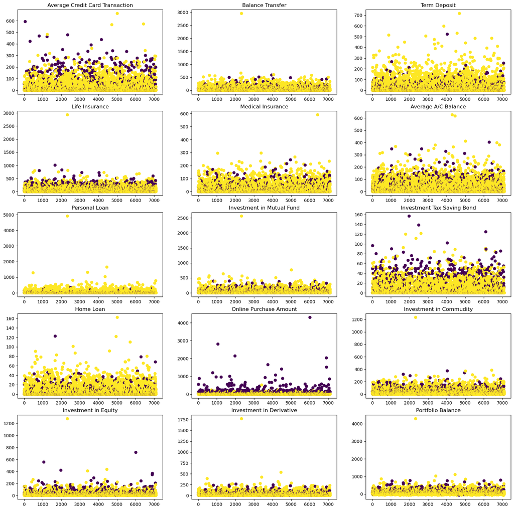

```python
%matplotlib inline
numeric_cols = feature_train.select_dtypes(include = np.number) ### selects numeric columns
numeric_cols.drop(['REF_NO','year_last_moved'],axis=1,inplace=True)

cols = list(numeric_cols.columns)

cols_index = 0
fig, ax = plt.subplots(5, 3, figsize=(20, 20))

for i in range(5):
        for j in range(3):
            if cols_index < len(cols):
               ax[i][j].scatter(y=feature_train[cols[cols_index]], x=feature_train[cols[cols_index]].index, c= target_train)
               ax[i][j].set_title(cols[cols_index])
               cols_index += 1


#plt.tight_layout()
#plt.show()
```

There is this one point whose behaviour is very different from the rest of the points and this point will cause noise in our prediction so we will remove it.

```python
## Dropping the row with different behaviour
feature_train.drop([2329], axis=0, inplace=True)
target_train.drop([2329], inplace=True)

feature_train.reset_index(drop=True, inplace=True)
target_train.reset_index(drop=True, inplace=True)
```

#### 1.5 Data preprocessing

```python
feature_train.info()
```

```
<class 'pandas.core.frame.DataFrame'>
RangeIndex: 7107 entries, 0 to 7106
Data columns (total 31 columns):
 #   Column                           Non-Null Count  Dtype
---  ------                           --------------  -----
 0   REF_NO                           7107 non-null   int64
 1   children                         7107 non-null   object
 2   age_band                         7107 non-null   object
 3   status                           7107 non-null   object
 4   occupation                       7107 non-null   object
 5   occupation_partner               7107 non-null   object
 6   home_status                      7107 non-null   object
 7   family_income                    7107 non-null   object
 8   self_employed                    7107 non-null   object
 9   self_employed_partner            7107 non-null   object
```

[output cut: 23 more lines]

```python
train_uniq_values = {}
```

#### 1.5.1 Converting actual numeric column to numeric from object

```python
def child_age_to_numeric(child_data,unique_values):
    # unique values are those values present in that which we need to pass to convert them to numeric
    # what if in future get some value which is not present in our unique value list for validation/testing at this point
    # our model will colapse so to avoid this we will convert everyother value which is not in our uniq_val list to zero
    # because of mode as it is a categorical column.
    child_data[~(child_data.isin(unique_values))] = "Zero" # convert values not in unique list to zero
    child_data[child_data=='Zero'] = 0 #converts to numeric 0, first they filtered the Zero contain values and replaced them
    child_data[child_data=='4+'] = 4
    child_data = pd.to_numeric(child_data)
    return child_data

uniq_values = feature_train['children'].unique() # taking unique values from column to pass it into function.

children_numeric = child_age_to_numeric(feature_train['children'] , uniq_values) # calling function

feature_train.drop(['children'], axis=1, inplace=True) ### drops the children column

feature_train['children'] = children_numeric # creating new column and adding those values to that column.

# now you have to store unique values in the form of column name as key and values as values but you have to convert values
# to list as they are in the form of array.

train_uniq_values['children'] = list(uniq_values)
```

```python
def age_band_converter(age_data,uniq_values):

    def __split (x):
        splits = x.split('-')
        left_value = int(splits[0])
        right_value = int(splits[1])
        mean = (left_value + right_value)/2
        return mean

    age_data[~(age_data.isin(uniq_values))] = '45-50' # for those value which are not present in this column is occur then
    # convert them to 36-40 age band

    age_data[age_data == 'Unknown'] = '45-50' # converting unknown ages to  mode value as it's categorical column

    age_data[age_data == '71+' ] = '71-75'

    mean_values = age_data.apply(__split)
    # The apply method in pandas is similar to a for loop in the sense that it allows you to iterate over elements in a
    # DataFrame or Series and apply a function to each element. However, there are some key differences:
    return mean_values

uniq_values = feature_train['age_band'].unique()

age_band_numeric = age_band_converter (feature_train['age_band'] , uniq_values)

feature_train.drop(['age_band'] , axis = 1 , inplace = True)

feature_train['age_band'] = age_band_numeric

train_uniq_values['age_band'] = list(uniq_values)
```

```python
def gender_converter_to_numeric (gender_data , uniq_values):
    gender_data[~(gender_data.isin(uniq_values))] = 'Female'
    gender_data[gender_data == 'Unknown'] = 'Female'
    # after this we can also use label or one hot encoding but since we have created a function we will do it manually
    gender_data[gender_data == 'Female'] = 1
    gender_data[gender_data == 'Male'] = 0
    gender_data = pd.to_numeric(gender_data)
    return gender_data

uniq_values = feature_train['gender'].unique()

gender_numeric = gender_converter_to_numeric(feature_train['gender'] , uniq_values)

feature_train.drop(['gender'],axis = 1, inplace = True)

feature_train['gender'] = gender_numeric

train_uniq_values['gender'] = list(uniq_values)
```

#### 1.5.2 Removing Unwanted columns

```python
columns_to_drop = ['REF_NO','post_code','post_area','year_last_moved']
feature_train.drop(['REF_NO','post_code','post_area','year_last_moved','region','TVarea'] , axis = 1 , inplace = True)
```

#### 1.5.3 Missing value treatment

```python
missing_value_replacement = {}
missing_value_replacement
```

```
{}
```

```python
columns_name = feature_train.columns
for i in columns_name:
   missing_value_replacement[i] = [feature_train[i].value_counts().index[0]]
```

Actually this are numeric continuous columns therefore we need to replace missing value with mean or median not with mode so i modified the values ovwr here

```python
missing_value_replacement['Balance Transfer'] = [16.975]
missing_value_replacement['Life Insurance'] = [30.0]
missing_value_replacement['Average A/C Balance'] = [15.00]
missing_value_replacement['Investment in Mutual Fund'] = [23.47]
missing_value_replacement['Investment in Commudity'] = [23.79]
missing_value_replacement['Investment in Equity'] = [12.82]
missing_value_replacement['Investment in Derivative'] = [20.89]
missing_value_replacement['Portfolio Balance'] = [65.38]
```

```python
one_hot_column = ['status', 'occupation', 'occupation_partner', 'home_status', 'self_employed', 'self_employed_partner' , 'family_income']

encoder = OneHotEncoder()

encoder.fit(feature_train[one_hot_column])

encoded_data = pd.DataFrame(encoder.transform(feature_train[one_hot_column]).toarray())

encoded_data.columns = encoder.get_feature_names_out()

feature_train.drop(one_hot_column , axis=1 , inplace = True)

feature_train = pd.concat([feature_train, encoded_data], axis=1)
```

```python
# stores the names of the columns we removed
with open('columns_to_remove.pickle', 'wb') as f:
    pickle.dump(columns_to_drop , f)

# store the unique values in the columns
with open('columns_uniq_values.pickle','wb') as f:
    pickle.dump(train_uniq_values, f)

# store one hot encoder object (bcoz we need same preprocessing on validation set as we did on training set)
with open('column_encoder.pickle' , 'wb') as f:
    pickle.dump(encoder , f)

# Store values we will use to replace missing values
with open('missing_value_replacement.pickle', 'wb') as f:
    pickle.dump(missing_value_replacement,f)

# store one hot encoded column
with open('one_hot_column.pickle','wb') as f:
    pickle.dump(one_hot_column,f)

with open('column_sequence.pickle', 'wb') as f:
  pickle.dump(list(feature_train.columns), f)
```

```python
with open ('columns_to_remove.pickle', 'rb') as f:
    cols_to_remove = pickle.load(f)

with open('columns_uniq_values.pickle','rb') as f:
    uniq_values = pickle.load(f)

with open('missing_value_replacement.pickle','rb') as f:
    missing_replacement = pickle.load(f)

with open('column_encoder.pickle','rb') as f:
    encoder = pickle.load(f)

with open('one_hot_column.pickle','rb') as f:
    one_hot_column_names = pickle.load(f)

with open('column_sequence.pickle', 'rb') as f:
  column_seq = pickle.load(f)

def children_numeric_converter(children_data, unique_values):
  children_data[~(children_data.isin(unique_values))] = "Zero" # This replaces every other value to Zero
  children_data[children_data=='Zero'] = 0  # Converts Zero to numeric 0
  children_data[children_data=='4+'] = 4    # Converts 4+ to 4
  children_data = pd.to_numeric(children_data) # Converts children_data to numeric
  return children_data

def ageband_numeric_converter(ageband_data, uniq_values):

  def __split(x):
    splits = x.split('-')
    left_val = splits[0]
    right_val = splits[1]
    mean = (float(left_val) + float(right_val))/2
    return mean

  ageband_data[~(ageband_data.isin(uniq_values))] = '45-50'
  ageband_data[ageband_data=='71+'] = '71-75'
  ageband_data[ageband_data=='Unknown'] = '45-50'
  mean_vals = ageband_data.apply(__split)
  return mean_vals

def gender_numeric_converter(gender_data, uniq_values):
  gender_data[~(gender_data.isin(uniq_values))] = 'Female'
  gender_data[gender_data=='Unknown'] = 'Female'
  gender_data[gender_data=='Male'] = 0
  gender_data[gender_data=='Female'] = 1
  gender_data = pd.to_numeric(gender_data)
  return gender_data


def preprocess_val_test(data):
  ### Drop columns ####
  for column in cols_to_remove:
    data.drop([column], axis=1, inplace=True)

  children_uniq = uniq_values['children']
  children_numeric = children_numeric_converter(data['children'], children_uniq)
  data.drop(['children'], axis=1, inplace=True)
  data['children'] = children_numeric

  ageband_uniq = uniq_values['age_band']
  ageband_numeric = ageband_numeric_converter(data['age_band'], ageband_uniq)
  data.drop(['age_band'], axis=1, inplace=True)
  data['age_band'] = ageband_numeric

  gender_uniq = uniq_values['gender']
  gender_numeric = gender_numeric_converter(data['gender'], gender_uniq)
  data.drop(['gender'], axis=1, inplace=True)
  data['gender'] = gender_numeric

  ### Missing value Imputation ######
  missing_value_columns = list(data.isnull().sum()[data.isnull().sum()>0].index)

  for column in missing_value_columns:
    replacement_values = missing_replacement[column]
    if len(replacement_values) != 1:
      replace_with = np.random.choice(replacement_values, data[column].isnull().sum())
    else:
      replace_with = replacement_values[0]
    data[data[column].isnull(), column] = replace_with


  #### One hot encoding ######
  one_hot_converted_columns = ['status', 'occupation', 'occupation_partner', 'home_status', 'self_employed', 'self_employed_partner', 'family_income']
  encoded_data = pd.DataFrame(encoder.transform(data[one_hot_converted_columns]).toarray())
  encoded_data.columns = encoder.get_feature_names_out()
  data.drop(one_hot_converted_columns, axis=1, inplace=True)
  data = pd.concat([data, encoded_data], axis=1)


  ### Ensure that the column ordering and the columns are same #####
  data = data[column_seq]

  return data
```

```python
feature_test = preprocess_val_test(feature_test)
```

[output not shown]

### 2 Modelling

1st we will convert 1 and 2 to 0 and 1 for our ez

```python
target_train[target_train == 2] = 0
target_train[target_train == 1] = 1

target_test[target_test == 2] = 0
```

#### 2.1 KNN Model

```python
best_knn = KNeighborsClassifier(n_neighbors=5, weights="uniform",p=2)
best_knn.fit(feature_train,target_train)
```

```
KNeighborsClassifier()
```

```
<sklearn.metrics._plot.confusion_matrix.ConfusionMatrixDisplay at 0x23ef7162050>
```

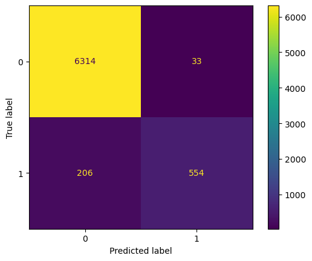

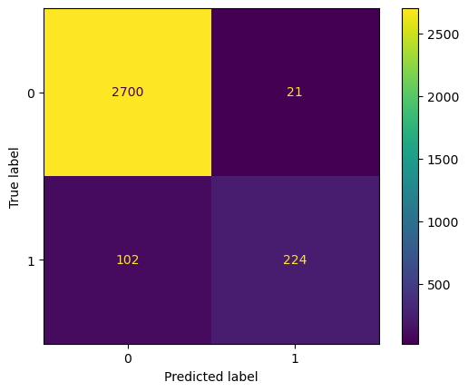

```python
tr = best_knn.predict(feature_train)
pr = best_knn.predict(feature_test)

ConfusionMatrixDisplay.from_predictions(target_train, tr)
ConfusionMatrixDisplay.from_predictions(target_test, pr)
```

```python
train_f1 = f1_score(target_train, tr)
val_f1 = f1_score(target_test, pr)

print('Train F1 Score - {}'.format(train_f1))
print('Val F1 Score - {}'.format(val_f1))
```

```
Train F1 Score - 0.8225686711210097
Val F1 Score - 0.7845884413309984
```

The best accuracy we got till now for KNN Model :Train F1 Score - 0.8225686711210096 Val F1 Score - 0.7845884413309983

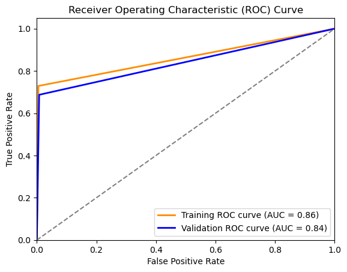

```python
# Compute ROC curve and AUC for training set
fpr_train, tpr_train, _ = roc_curve(target_train,tr)
roc_auc_train = auc(fpr_train, tpr_train)

# Compute ROC curve and AUC for validation set
fpr_val, tpr_val, _ = roc_curve(target_test,pr)
roc_auc_val = auc(fpr_val, tpr_val)

# Plot ROC curve
plt.figure()
plt.plot(fpr_train, tpr_train, color='darkorange', lw=2, label=f'Training ROC curve (AUC = {roc_auc_train:.2f})')
plt.plot(fpr_val, tpr_val, color='blue', lw=2, label=f'Validation ROC curve (AUC = {roc_auc_val:.2f})')
plt.plot([0, 1], [0, 1], color='gray', linestyle='--')
plt.xlim([0.0, 1.0])
plt.ylim([0.0, 1.05])
plt.xlabel('False Positive Rate')
plt.ylabel('True Positive Rate')
plt.title('Receiver Operating Characteristic (ROC) Curve')
plt.legend(loc='lower right')
plt.show()
```

#### 2.2 Logistic Regression

```python
scaler = StandardScaler()
feature_train_log = np.log1p(feature_train)  # Apply log transformation
scaler.fit_transform(feature_train_log)  # Standardize the transformed data
scaled_data = pd.DataFrame(scaler.transform(feature_train),columns = feature_train.columns)
```

```python
scaler = StandardScaler()
feature_test_log = np.log1p(feature_test)  # Apply log transformation
scaler.fit_transform(feature_test_log)
StandardScaler(copy=True,with_mean = True,with_std = True)
scale_data = pd.DataFrame(scaler.transform(feature_test),columns = feature_test.columns)
```

```python
best_lr = LogisticRegression(max_iter=300, solver="newton-cg",  class_weight = {0:1.2, 1:4.2},C=2,penalty='l2')

best_lr.fit(scaled_data, target_train)
```

```
LogisticRegression(C=2, class_weight={0: 1.2, 1: 4.2}, max_iter=300,
                   solver='newton-cg')
```

```python
tr_pred2 = best_lr.predict(scaled_data) #### Training prediction
val_pred2 = best_lr.predict(scale_data)
```

```python
train_f1 = f1_score(target_train, tr_pred2)
val_f1 = f1_score(target_test, val_pred2)

print('Train F1 Score - {}'.format(train_f1))
print('Val F1 Score - {}'.format(val_f1))
```

```
Train F1 Score - 0.7314148681055156
Val F1 Score - 0.7544581618655694
```

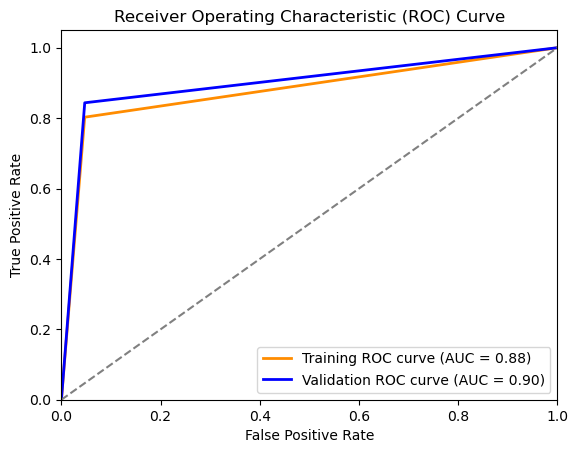

```python
# Compute ROC curve and AUC for training set
fpr_train, tpr_train, _ = roc_curve(target_train,tr_pred2)
roc_auc_train = auc(fpr_train, tpr_train)

# Compute ROC curve and AUC for validation set
fpr_val, tpr_val, _ = roc_curve(target_test,val_pred2)
roc_auc_val = auc(fpr_val, tpr_val)

# Plot ROC curve
plt.figure()
plt.plot(fpr_train, tpr_train, color='darkorange', lw=2, label=f'Training ROC curve (AUC = {roc_auc_train:.2f})')
plt.plot(fpr_val, tpr_val, color='blue', lw=2, label=f'Validation ROC curve (AUC = {roc_auc_val:.2f})')
plt.plot([0, 1], [0, 1], color='gray', linestyle='--')
plt.xlim([0.0, 1.0])
plt.ylim([0.0, 1.05])
plt.xlabel('False Positive Rate')
plt.ylabel('True Positive Rate')
plt.title('Receiver Operating Characteristic (ROC) Curve')
plt.legend(loc='lower right')
plt.show()
```

#### 2.3 Random Forest Classifier

```python
from sklearn.ensemble import RandomForestClassifier
```

```python
best_clf_1 = RandomForestClassifier(class_weight={0: 1, 1: 3},
                                max_depth=None,
                                max_features=0.5,
                                min_samples_split=50,
                                n_estimators=500,
                                 n_jobs = -1)

best_clf_1.fit(feature_train, target_train)
```

```
RandomForestClassifier(class_weight={0: 1, 1: 3}, max_features=0.5,
                       min_samples_split=50, n_estimators=500, n_jobs=-1)
```

```python
with open('2nd_project_model.pickle','wb') as f:
    pickle.dump(best_clf_1,f)
```

```
<sklearn.metrics._plot.confusion_matrix.ConfusionMatrixDisplay at 0x23ef66fe710>
```

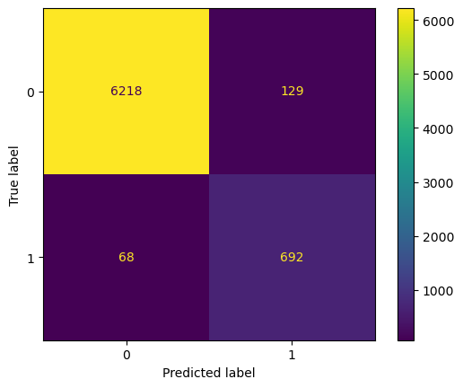

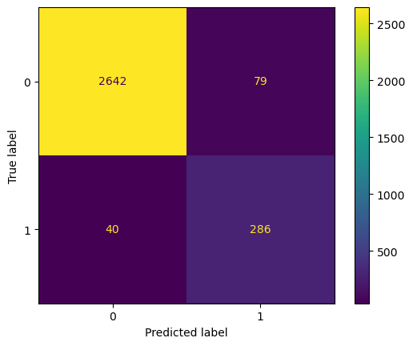

```python
tr_pred_best = best_clf_1.predict(feature_train) #### Training prediction
val_pred_best = best_clf_1.predict(feature_test)

ConfusionMatrixDisplay.from_predictions(target_train, tr_pred_best)
ConfusionMatrixDisplay.from_predictions(target_test, val_pred_best)
```

```python
train_f1 = f1_score(target_train, tr_pred_best)
val_f1 = f1_score(target_test, val_pred_best)

print('Train F1 Score - {}'.format(train_f1))
print('Val F1 Score - {}'.format(val_f1))
```

```
Train F1 Score - 0.8753953194180898
Val F1 Score - 0.8277858176555717
```

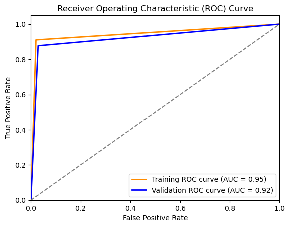

```python
fpr_train, tpr_train, _ = roc_curve(target_train,tr_pred_best)
roc_auc_train = auc(fpr_train, tpr_train)

# Compute ROC curve and AUC for validation set
fpr_val, tpr_val, _ = roc_curve(target_test,val_pred_best)
roc_auc_val = auc(fpr_val, tpr_val)

# Plot ROC curve
plt.figure()
plt.plot(fpr_train, tpr_train, color='darkorange', lw=2, label=f'Training ROC curve (AUC = {roc_auc_train:.2f})')
plt.plot(fpr_val, tpr_val, color='blue', lw=2, label=f'Validation ROC curve (AUC = {roc_auc_val:.2f})')
plt.plot([0, 1], [0, 1], color='gray', linestyle='--')
plt.xlim([0.0, 1.0])
plt.ylim([0.0, 1.05])
plt.xlabel('False Positive Rate')
plt.ylabel('True Positive Rate')
plt.title('Receiver Operating Characteristic (ROC) Curve')
plt.legend(loc='lower right')
plt.show()
```

Conclusion : 1] By looking at AUC value we found out that Random Forest Classifier is our best model

```python
raw_data.columns
```

```
Index(['REF_NO', 'children', 'age_band', 'status', 'occupation',
       'occupation_partner', 'home_status', 'family_income', 'self_employed',
       'self_employed_partner', 'year_last_moved', 'TVarea', 'post_code',
       'post_area', 'Average Credit Card Transaction', 'Balance Transfer',
       'Term Deposit', 'Life Insurance', 'Medical Insurance',
       'Average A/C Balance', 'Personal Loan', 'Investment in Mutual Fund',
       'Investment Tax Saving Bond', 'Home Loan', 'Online Purchase Amount',
       'Revenue Grid', 'gender', 'region', 'Investment in Commudity',
       'Investment in Equity', 'Investment in Derivative',
       'Portfolio Balance'],
      dtype='object')
```